# Clase 1 - Asignando propiedades estéticas a los datos

A intentarlo. Asignemos la columna `day_of_year` a la posición en el eje de las $x$, la columna `temperature` a las $y$, y usemos `geom_line()` para mostrar los datos.

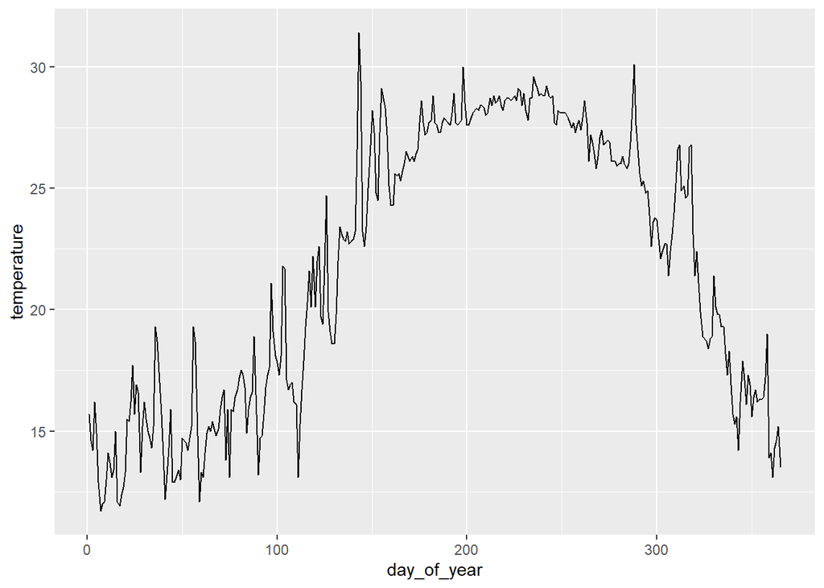

```r
ggplot(temps_beirut, aes(x = day_of_year, y = temperature)) +
  geom_line()
```

Ahora otra vez, pero usando `geom_point()` en vez de `geom_line()`.

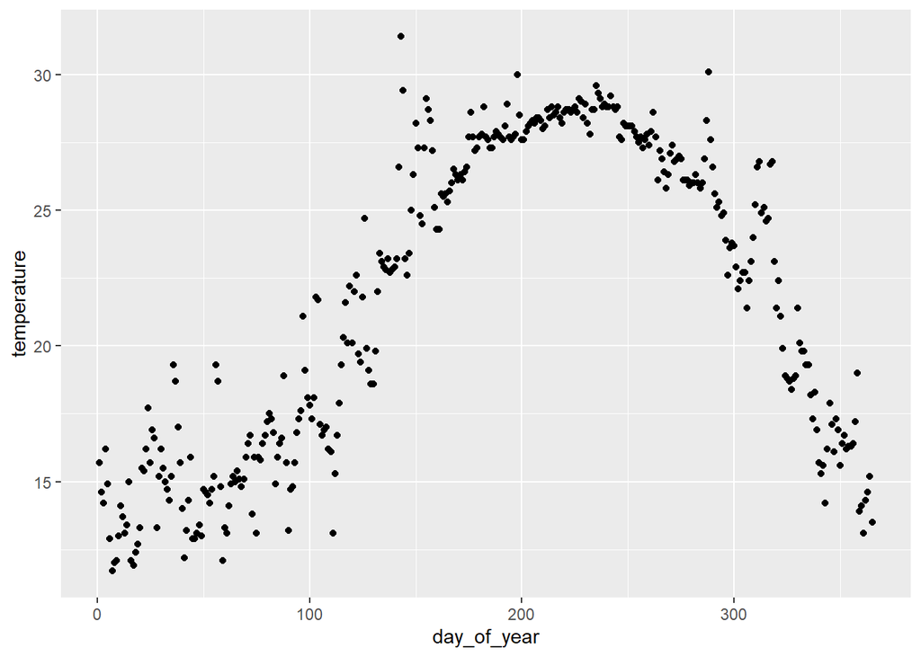

```r
ggplot(temps_beirut, aes(x = day_of_year, y = temperature)) +
  geom_point()
```

Y ahora intercambiemos las columnas que antes asignamos a las $x$ y a las $y$:

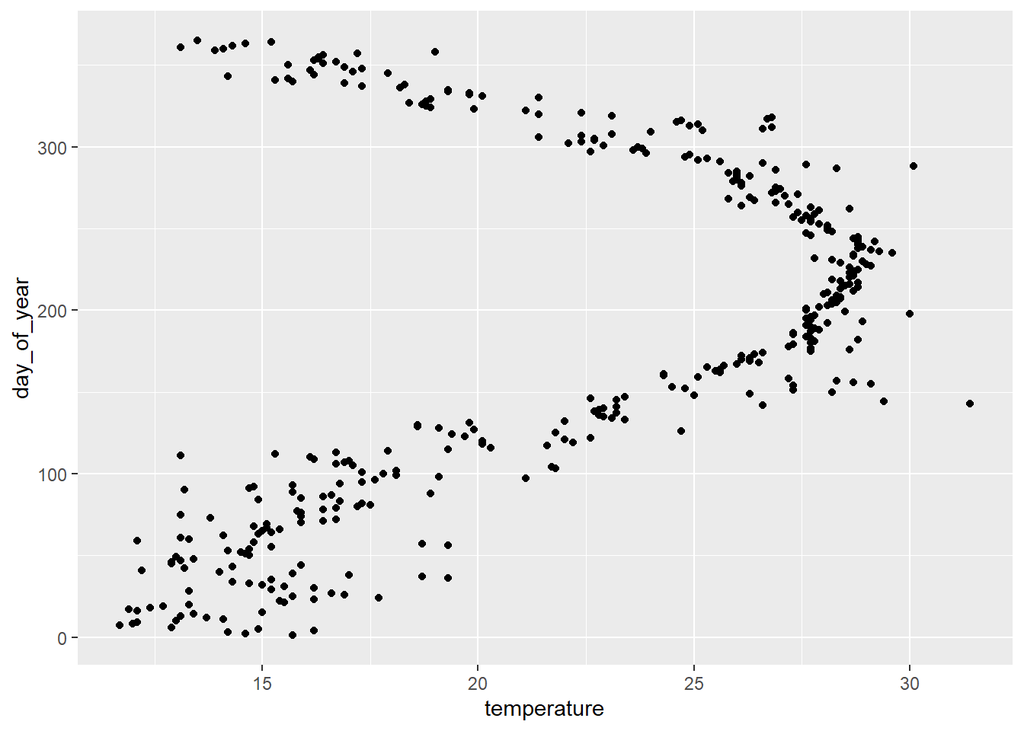

```r
ggplot(temps_beirut, aes(x = temperature, y = day_of_year)) +
  geom_point()
```

## Empelando *geoms* más complejas

Pueden elegir entre una variada colección de geoms para hacer toda clase de gráficos. Por ejemplo, `geom_boxplot()` crea *boxplots* (o [“diagramas de caja”](https://economipedia.com/definiciones/diagrama-de-caja.html)). Al hacer boxplots es común mostrar un gráfico separado para cada categoría presente en la data a mostrar, usando para eso el eje de las $x$ o de las $y$.

¡Hagamos eso mismo! Pongamos `month` en el eje $x$ (como variable categórica), `temperature` en el eje de las $y$, y a dibujar cajas con `geom_boxplot()`.

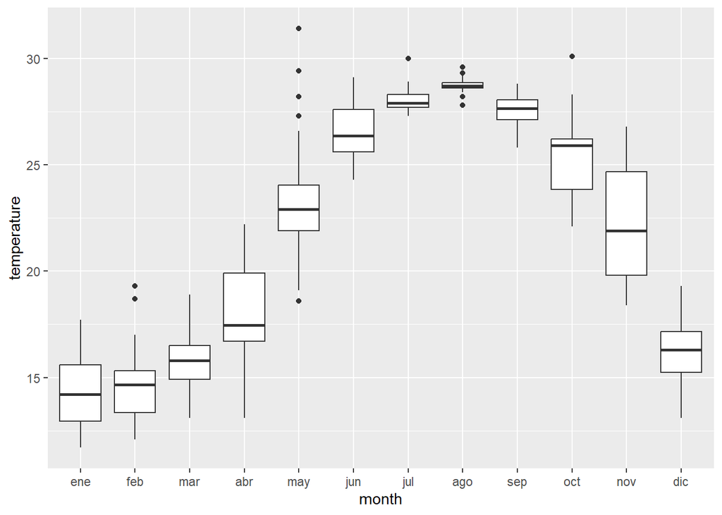

```r
ggplot(temps_beirut, aes(x = month, y = temperature)) +
  geom_boxplot()
```

¿Qué pasa si lo damos vuelta?

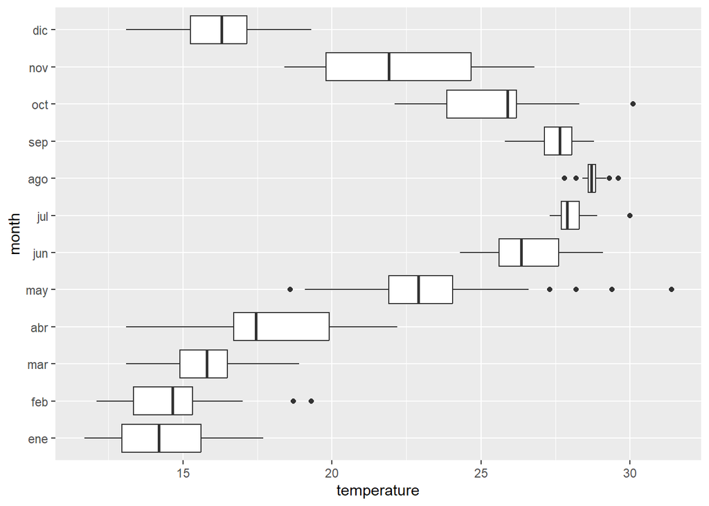

```r
ggplot(temps_beirut, aes(x = temperature, y = month)) +
  geom_boxplot()
```

Más adelante vamos a regresar a los boxplots, explicando cómo se interpretan.

## Incorporando colores a las visualizaciones

Ahora pasamos a trabajar con el dataset `temps`, que es similar a `temps_beirut` pero contiene registros para tres ubicaciones adicionales:

```r
temps
```

```
## # A tibble: 1,460 × 7
##    region                      country city  month day_of_year  year temperature
##    <chr>                       <chr>   <chr> <ord>       <dbl> <dbl>       <dbl>
##  1 Middle East                 Lebanon Beir… ene             1  2019        15.7
##  2 Europe                      Ukraine Kiev  ene             1  2019        -0.1
##  3 South/Central America & Ca… Hondur… Tegu… ene             1  2019        19.3
##  4 North America               US      Miam… ene             1  2019        24.3
##  5 Middle East                 Lebanon Beir… ene             2  2019        14.6
##  6 Europe                      Ukraine Kiev  ene             2  2019         0.3
##  7 South/Central America & Ca… Hondur… Tegu… ene             2  2019        20.6
##  8 North America               US      Miam… ene             2  2019        24.4
##  9 Middle East                 Lebanon Beir… ene             3  2019        14.2
## 10 Europe                      Ukraine Kiev  ene             3  2019        -0.8
## # ℹ 1,450 more rows
```

Hagamos un gráfico de líneas mostrando `temperature` para cada `day_of_year`, usando el atributo estético *color* para diferencias las líneas según la ciudad que representan.

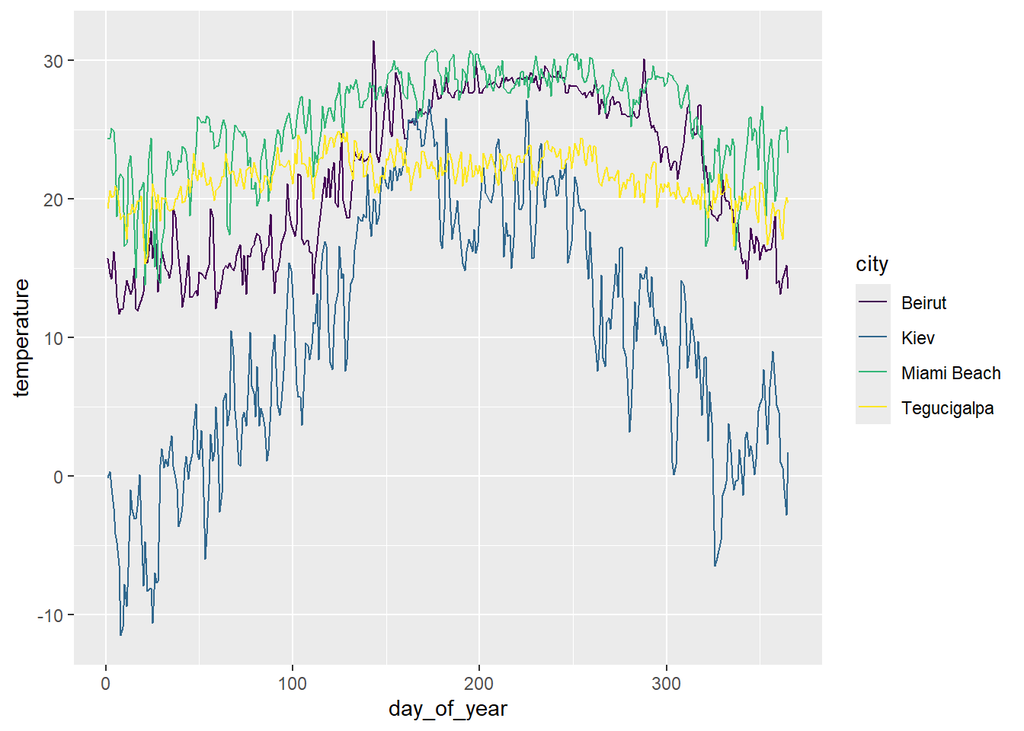

```r
ggplot(temps, aes(x = day_of_year, y = temperature, color = city)) +
  geom_line()+
  scale_color_viridis_d()
```

Vamos de nuevo, esta vez usando `city` como variable en el eje $y$, y `temperature` a representar con color. Este gráfico queda mejor usando `geom_point()`.

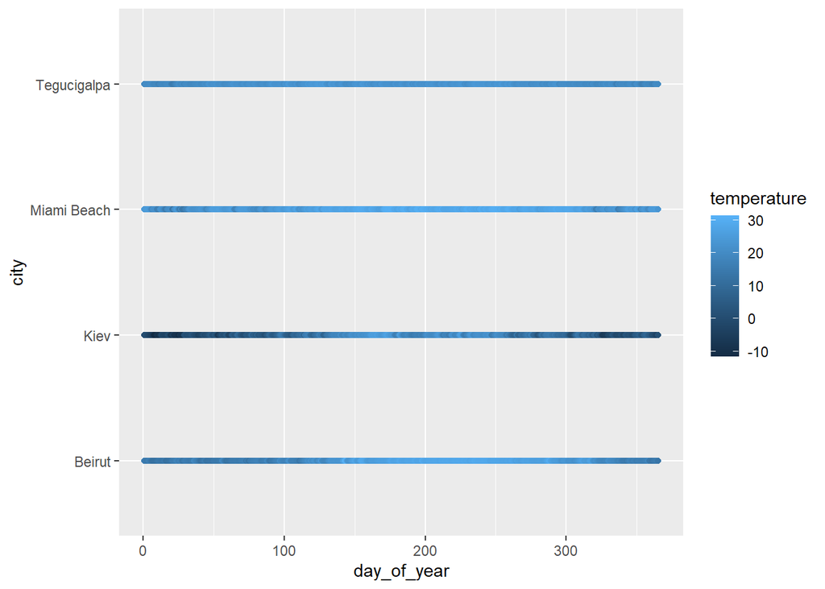

```r
ggplot(temps, aes(x = day_of_year, y = city, color = temperature)) +
  geom_point()
```

En estos dos ejemplos utilizamos el color como atributo estético para mostrar información. Sin embargo, lo estamos haciendo de dos formas muy distintas. En el gráfico de líneas, usamos el color como una herramienta para *distinguir* variables categóricas. Mientras que en el gráfico de puntos, lo usamos para representar una escala secuencial de valores. Dicha escala permite indicar de manera clara qué valores son más grandes que otros, y qué tan distantes son los valores entre sí.

La teoría del color es un tema en si mismo. Debido a las complejidades subyacentes en esta temática, que implicaría ponernos a hablar de la visión humana, el cerebro y la percepción, podríamos dedicar una clase entera a ello. Sin embargo, como no tenemos ese tiempo, si es necesario remarcar que los colores que elijamos en un gráfico van a transmitir un mensaje y tienen poder ser interpretados para el público general. Por ejemplo, no es lo mismo si en un gráfico pinto la barra de mujeres de rosa y la de varones de azul; que si las pinto naranja y verde. Por otro lado, hay ciertos colores que dificultan la interpretación para las personas con daltonismo.

Por suerte, R tiene paquetes con paletas de colores que nos permiten resolver algunas de estas cuestiones. Uno de los más popular es `viridis`, cuya paleta de colores están diseñadas para ser:

- coloridas, brindando una paleta amplia para mostrar diferencias con claridad;
- perceptualmente uniformes, lo que significa que los valores más cercanos entre ellos tendrán colores más parecidos y los que están más alejados tendrán colores distintos de manera consistente;
- interpretados fácilmente por personas con daltonísmo;
- interpretables si se imprimen en escala de grises.

Usar las paletas viridis es tan simple como añadir una línea de código:

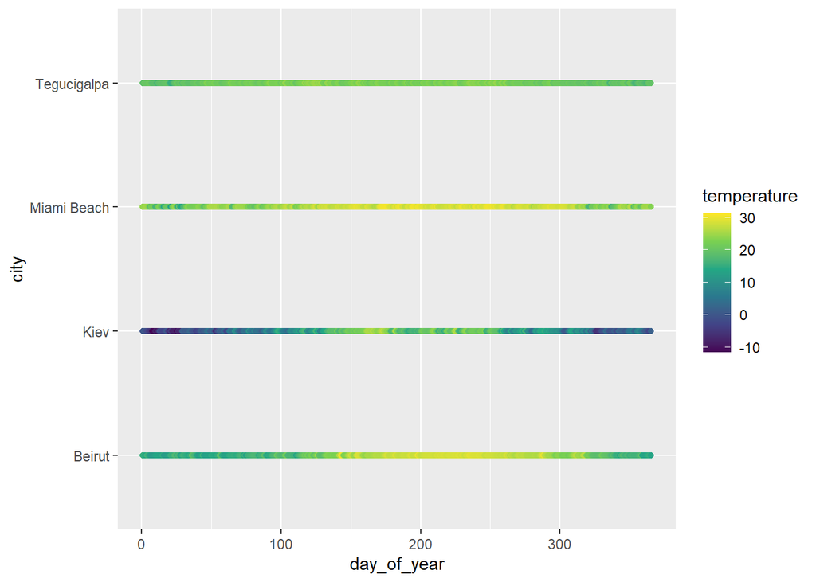

```r
library(viridis)

ggplot(temps, aes(x = day_of_year, y = city, color = temperature)) +
  geom_point()+
  scale_color_viridis_c()
```

## Atributo estético `fill`

Algunas geoms permiten usar el atributo estético `fill`, que es similar `color` pero se aplica como relleno, “pintando” por dentro áreas como las barras de un gráfico o las regiones en un mapa (`color`, en cambio, se usa para líneas y puntos).

Por ejemplo, podemos usar el atributo estético `fill` con `geom_boxplot()` para pintar el interior de cada caja.

Vamos a probarlo. Generemos un gráfico de `month` en las $x$, `temperature` en las $y$, y coloreemos el interior de cada caja según su ciudad.

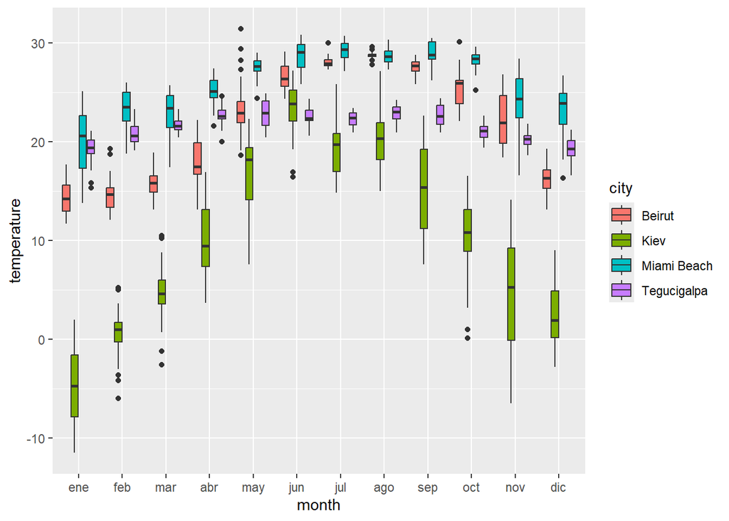

```r
ggplot(temps, aes(x = month, y = temperature, fill = city)) +
  geom_boxplot()
```

¿Cómo nos quedaría con la paleta viridis?

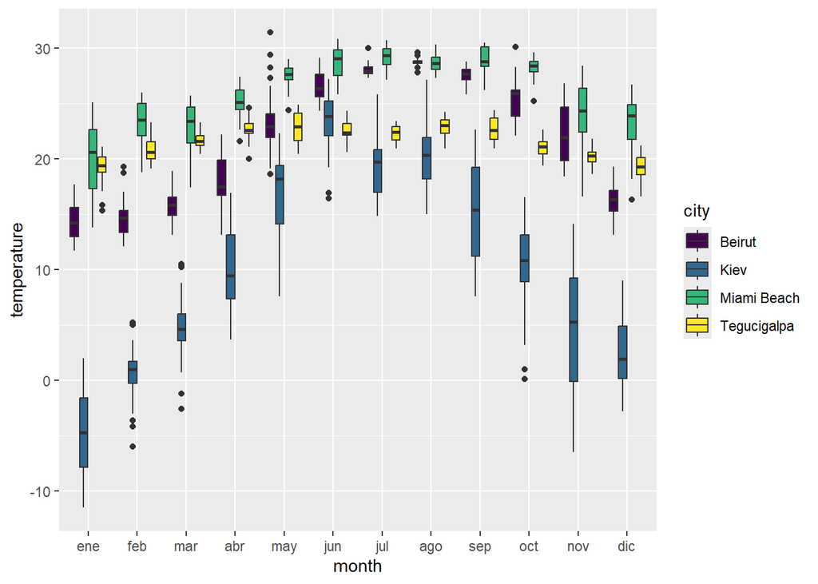

```r
ggplot(temps, aes(x = month, y = temperature, fill = city)) +
  geom_boxplot()+
  scale_fill_viridis_d()
```

¿Podemos pintar las líneas de las cajas según el mes, y pintar el interior según la ubicación?

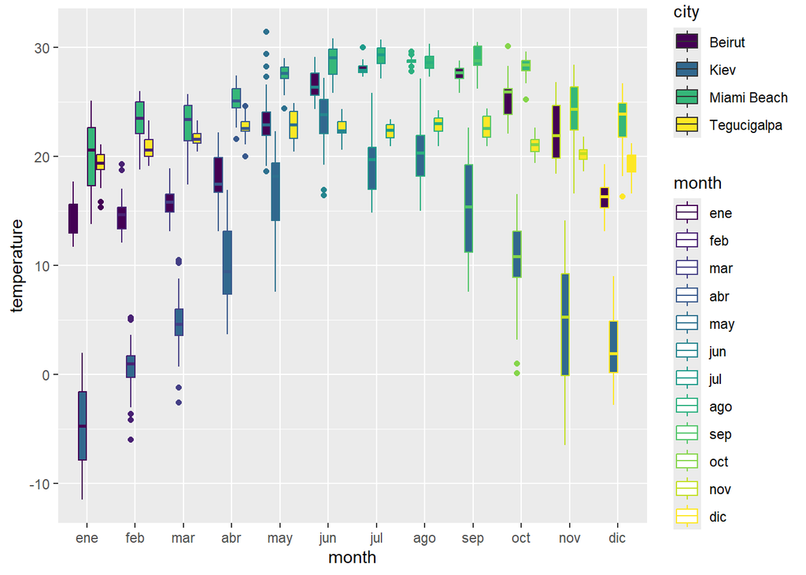

```r
ggplot(temps, aes(x = month, y = temperature, color = month, fill = city)) +
  geom_boxplot()+
  scale_fill_viridis_d()
```

El gráfico que obtuvimos funciona como recordatorio de que en muchas ocasiones la cantidad de recursos visuales volcados resulta inversamente proporcional a su legibilidad.

Si bien, en general simple es bueno, también conviene saber que podemos combinar varias estéticas dentro de `aes()` cuando resulte necesario.

## Atributos estéticos fijos

Muchos de los atributos estéticos, como `color`, `fill` y `size` que cambia el tamaño de puntos y grosor de líneas, pueden ser usados como parámetros fijos para una geom. Es decir, que no cambien de acuerdo a los valores de una variable sino que son iguales para todos las figuras graficadas. Esto se logra definiendo un valor específico fuera del llamado a `aes()`.

Por ejemplo, `color = "blue"` en lugar de la asignación de una variable, como `aes(color = city)`.

Nótese la diferencia: dentro de la función `aes()` no definimos colores específicos, ggplot se encarga de eso. Sólo decimos que los valores encontrados en la columna `city` deben corresponder a diferentes colores. En las próximas clases vamos a aprender como indicarle a ggplot que use escalas de colores específicas cuando asigna colores por variable.

Intentémoslo con el ejemplo del boxplot en la sección anterior. Asignemos el color como atributo dependiente de la ciudad, pero dejemos el color de las líneas fijo en color azul marino (`"navy blue"`) de acuerdo a los [nombres de colores que R sabe interpretar](http://www.stat.columbia.edu/~tzheng/files/Rcolor.pdf)

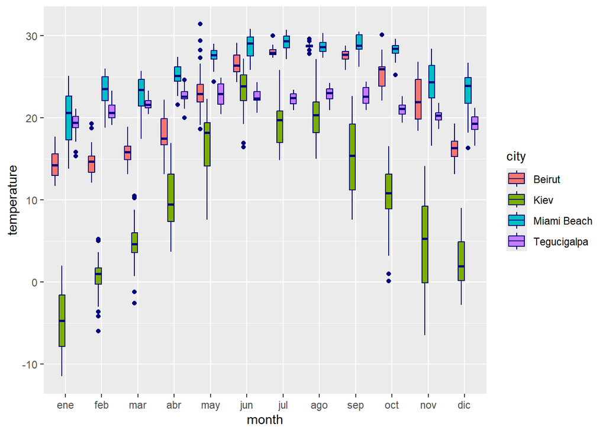

```r
ggplot(temps, aes(x = month, y = temperature, fill = city)) +
  geom_boxplot(color = "navyblue")
```

Ahora al revés, asignemos la variable `city` al color de las líneas, pero dejemos el relleno de las cajas fijo en color `"navyblue"`.

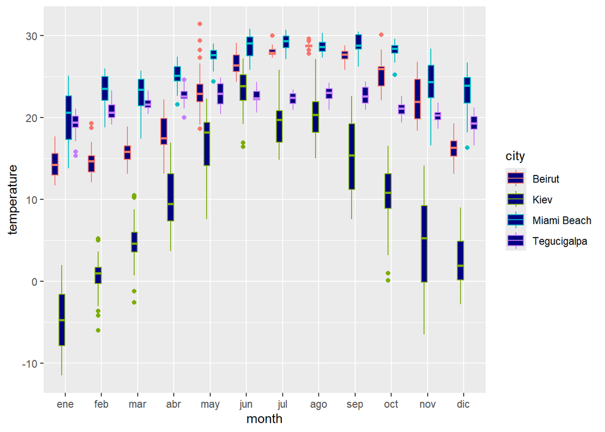

```r
ggplot(temps, aes(x = month, y = temperature, color = city)) +
  geom_boxplot(fill = "navyblue")
```

Por último, vale la pena aclarar que si bien este módulo presenta un sesgo importante de preferencia frente a las paletas viridis, existe una amplia variedad de paquetes con paletas de colores. [`wesanderson`](https://github.com/karthik/wesanderson), con colores de películas de Wes Anderson, o [`SailorMoonR`](https://github.com/morgansleeper/SailorMoonR) con colores de Sailor Moon.

¡Y con eso terminamos!